# New Manager Bounce

Here I want to see if there is any truth that a new manager makes a team perform better. To do this I am going to look at data from the current Premier League season, and summarise overall team statistics before and after a new manager is brought in!

## Getting Data

I downloaded Premier League data from the FPL API that I am going to read in here:

```r
# Packages
library(tidyverse)
library(extrafont)
library(ggrepel)
library(dplyr)
library(ggimage)
library(Metrics)
source('Prediction-Functions.R')

# Read data
PlayerData <- read_csv("FPL-Gameweeks-28.csv")
TeamColours <- read_csv("Team-Colours.csv")
```

I also want to get fixture information, which is available from Vaastav’s FPL GitHub repository.

```r
# Set github
Github <- "https://raw.githubusercontent.com/vaastav/Fantasy-Premier-League/master/data/2024-25/"

# Get fixture data
Fixtures <- read_csv(url(paste0(Github, "fixtures.csv"))) %>%
  select(event, id, team_a, team_h) %>% unique()

Teams <- read_csv(url(paste0(Github, "teams.csv"))) %>% select(id, name)
```

Next I am just adding the fixture information for each player, so I know which team each player plays every week.

```r
# Merge
PlayerData <- addFixtures(Fixtures, PlayerData)

# Add team names
Fixtures <- Fixtures %>% merge(Teams, by.x='team_a', by.y='id') %>%
  rename('name_a'='name') %>%
  merge(Teams, by.x='team_h', by.y='id') %>%
  rename('name_h'='name', 'fixture'='id', 'gameweek'='event')

# Add double gameweek for Man City and Aston Villa
Fixtures[233,3] <- 33
```

Next I am going to summarise attacking and defensive data for each team that brought in a new manager - this includes Everton, West Ham, Southampton, Wolves, Leicester and Man Utd.

```r
# Summarise data
TeamData <- PlayerData  %>%
  filter(team_name %in% c('Everton', 'West Ham', 'Southampton', 'Wolves', 'Leicester', 'Man Utd'))  %>%
  group_by(team_name, gameweek, opponent)  %>%
  summarise(match_xG=sum(expected_goals),
            match_xGC=max(expected_goals_conceded),
            match_G=sum(goals_scored),
            match_GC=max(goals_conceded))

# Modify totals for Everton double gameweek
TeamData$match_xG <- ifelse(TeamData$team_name=='Everton'&TeamData$gameweek==24, TeamData$match_xG/2, TeamData$match_xG)
TeamData$match_xGC <- ifelse(TeamData$team_name=='Everton'&TeamData$gameweek==24, TeamData$match_xGC/2, TeamData$match_xGC)
TeamData$match_G <- ifelse(TeamData$team_name=='Everton'&TeamData$gameweek==24, TeamData$match_G/2, TeamData$match_G)
TeamData$match_GC <- ifelse(TeamData$team_name=='Everton'&TeamData$gameweek==24, TeamData$match_GC/2, TeamData$match_GC)
```

## Summarising Data

Next I want to adjust these scores by opponent difficulty. To do this I will summarise team xGC and xG over a season for each team to adjust each gameweek!

```r
# Summarise data over season
TeamDataSeason <- PlayerData  %>%
  group_by(team_name, gameweek)  %>%
  summarise(match_xG=sum(expected_goals),
            match_xGC=max(expected_goals_conceded),
            games=max(starts))  %>%
  group_by(team_name)  %>%
  summarise(total_xG=sum(match_xG),
            total_xGC=sum(match_xGC),
            total_games=sum(games))  %>%
  group_by(team_name)  %>%
  summarise(mean_xG=total_xG/total_games,
            mean_xGC=total_xGC/total_games)  %>%
  rename('opponent'='team_name')

# Merge with TeamData
TeamData <- merge(TeamData, TeamDataSeason)

# Adjust xG and xGC
TeamData$match_xG <- TeamData$match_xG/TeamData$mean_xGC
TeamData$match_xGC <- TeamData$match_xGC/TeamData$mean_xG
TeamData$match_G <- TeamData$match_G/TeamData$mean_xGC
TeamData$match_GC <- TeamData$match_GC/TeamData$mean_xG
```

## Plotting Data

Now I can plot a performance ‘score’ which I will calculate by finding the mean of (xG - xGC) and (actual G - actual GC).

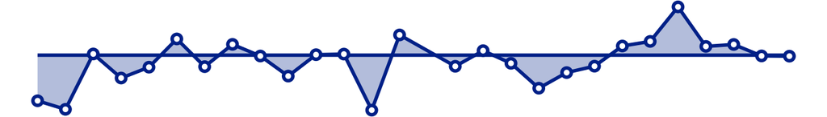

```r
# Performance score
TeamData$score <- ((TeamData$match_xG-TeamData$match_xGC)+(TeamData$match_G-TeamData$match_GC))/2

# Summarise for each gameweek (discounts double gameweeks)
TeamData <- TeamData  %>%
  group_by(team_name, gameweek)  %>%
  summarise(match_xG=mean(match_xG),
            match_xGC=mean(match_xGC),
            match_G=mean(match_G),
            match_GC=mean(match_GC),
            mean_xG=mean(mean_xG),
            mean_xGC=mean(mean_xGC),
            score=mean(score))

# Add team colours
TeamDataPlot <- merge(TeamData, TeamColours, by.x='team_name', by.y='team')
col <- as.character(TeamDataPlot$colour1)
names(col) <- as.character(TeamDataPlot$team_name)

# Plot
CreatePlot <- function(Team){

  # Plot
  plot <- ggplot(TeamDataPlot %>% filter(team_name==Team), aes(x=gameweek, y=score, group=team_name, fill=team_name, colour=team_name))+
    theme_void()+
    geom_ribbon(data=TeamDataPlot %>% filter(team_name==Team),
                aes(group=team_name, ymin=0, ymax=score), alpha=0.3, linewidth=1)+
    geom_point(size=3)+
    geom_point(size=1, colour='white')+
    scale_color_manual(values=col) +
    scale_fill_manual(values=col) +
    scale_x_continuous(n.breaks=28) +
    guides(colour='none', fill='none')+
    scale_y_continuous(expand=c(0.05,0.05))

  # Return
  return(plot)

}

# One plot
CreatePlot('Everton')
```

```r
# Save all plots
ggsave(plot=CreatePlot('Leicester'), filename="LeicesterNewManager.png", bg="transparent", device="png")
ggsave(plot=CreatePlot('Wolves'), filename="WolvesNewManager.png", bg="transparent", device="png")
ggsave(plot=CreatePlot('Man Utd'), filename="ManUtdNewManager.png", bg="transparent", device="png")
ggsave(plot=CreatePlot('Southampton'), filename="SouthamptonNewManager.png", bg="transparent", device="png")
ggsave(plot=CreatePlot('Everton'), filename="EvertonNewManager.png", bg="transparent", device="png")
ggsave(plot=CreatePlot('West Ham'), filename="WestHamNewManager.png", bg="transparent", device="png")
```

Here I am just extracting some extra info that I can use on my infographic!

```r
# Get means
M1 <- TeamDataPlot %>% filter(team_name=='West Ham', gameweek<21) %>% summarise(mean=mean(score))
M2 <- TeamDataPlot %>% filter(team_name=='West Ham', gameweek>20, gameweek<27) %>% summarise(mean=mean(score))
top3 <- TeamDataPlot %>% filter(team_name=='West Ham') %>% slice_max(score, n=3)
```

## Making a Graphic

Next I put the 6 output graphs into Adobe Illustrator and annotated them with the mean score for the first manager, and the mean score for the first 6 weeks of the second manager.

[figure not shown]

You can see from looking at my made up ‘score’ metric, while West Ham have slightly improved with Graham Potter, it is only really Everton who have shown a big improvement after being taken over by David Moyes - although this is probably distorted by their fabulous performances against Liverpool (2-2) and Leicester (4-0) in week 24.